# Between sample/ beta diversity of Microbes along a Salinity Gradient

Calla Bush St George

2024-04-24

# Goals

1. Load in phyloseq data with rooted tree.
2. Evaluate sequencing depth and remove sample.
3. Normalize the read counts between samples.
4. Calculate community dissimilarities. Numbers between 0 and 1. If 0, completely similar versus if they are 1, then they are completely dissimilar.
   1. *Sorensen*: Presence/ Absence. Weighted by number of shared taxa. Shared species as a binary-valye. Abundance-unweighted.
   2. *Bray-Curtis*: Relative abundance. Weighted by number of shared taxa. Shared abundant species: abundance weighted.
   3. *(Abundance) Weighted UNIFRAC*: Consider abundant species and where they fall on the tree.
5. Visualize the community data with two unconstricted ordinations:
   1. *PCoA*: Linear method. Uses matrix algebra to calculate eigenvalye. Calculate how much variation is explained by each axis. Can choose to view axis 1, 2, 3, etc. and plot them together.
   2. *NMDS*: Non-linear method. Collapse multiple axes into two (or three) dimensions. Can see more axes of variation into fewer axes. Always need to report a stress value. (Ideally less than 0.15)
6. Run statistics with PERMANOVA and betadispR.

# Setup

## Load Libraries

```r
#install.packages("vegan")
pacman::p_load(tidyverse, devtools, phyloseq, patchwork, vegan,
               install = FALSE)
```

## Load in colors

```r
station_colors <- c(
  "Shipping Channel" = "dodgerblue4",
  "Aransas Bay" = "dodgerblue2",
  "Copano West" = "#D9CC3C",
  "Copano East" = "#A0E0BA",
  "Mesquite Bay" = "#00ADA7")
```

## Load in data

```r
# Load in rooted phylogenetic tree!
load("data/03_Phylogenetic_Tree/phytree_preprocessed_physeq.RData")
unrooted_physeq_rm456
```

```
## phyloseq-class experiment-level object
## otu_table()   OTU Table:         [ 2676 taxa and 89 samples ]
## sample_data() Sample Data:       [ 89 samples by 47 sample variables ]
## tax_table()   Taxonomy Table:    [ 2676 taxa by 9 taxonomic ranks ]
## phy_tree()    Phylogenetic Tree: [ 2676 tips and 2674 internal nodes ]
```

```r
midroot_physeq_rm456
```

```
## phyloseq-class experiment-level object
## otu_table()   OTU Table:         [ 2676 taxa and 89 samples ]
## sample_data() Sample Data:       [ 89 samples by 47 sample variables ]
## tax_table()   Taxonomy Table:    [ 2676 taxa by 9 taxonomic ranks ]
## phy_tree()    Phylogenetic Tree: [ 2676 tips and 2675 internal nodes ]
```

# Explore Read Counts

## Raw Read Depth

```r
# Sequence depth will inform us on how we want to normalize our data
# Calculate the total number of reads per sample
raw_total_seqs_df <-
  unrooted_physeq_rm456 %>%
  # Calculate the sample read sums
  sample_sums() %>%
  data.frame()

# Name the column
colnames(raw_total_seqs_df)[1] <- "TotalSeqs"

head(raw_total_seqs_df)
```

```
##                   TotalSeqs
## 20210602-MA-ABB1F      4024
## 20210602-MA-ABB1P      3086
## 20210602-MA-ABB1W      5719
## 20210602-MA-ABS1F      3824
## 20210602-MA-ABS1P      3743
## 20210602-MA-ABS1W      4742
```

```r
# Make a histogram of raw reads
raw_seqs_histogram <-
  raw_total_seqs_df %>%
  ggplot(aes(x = TotalSeqs)) +
  geom_histogram(bins = 50) +
  scale_x_continuous(limits = c(0, 10000)) +
  labs(title = "Raw Sequencing Depth Distribution") +
  theme_bw()
```

## Remove lowly sequenced sample

```r
raw_rooted_physeq <-
  midroot_physeq_rm456 %>%
  # Remove lowly sequence sample that was outlier in alpha diversity analysis
  subset_samples(names != "20210615-MA-ABB2F") %>%
  # Any ASVs unique to the sample will also be removed
  prune_taxa(taxa_sums(.) > 0, .)

# Inspect
raw_rooted_physeq
```

```
## phyloseq-class experiment-level object
## otu_table()   OTU Table:         [ 2669 taxa and 88 samples ]
## sample_data() Sample Data:       [ 88 samples by 47 sample variables ]
## tax_table()   Taxonomy Table:    [ 2669 taxa by 9 taxonomic ranks ]
## phy_tree()    Phylogenetic Tree: [ 2669 tips and 2668 internal nodes ]
```

```r
# What is the minimum number of sequences
raw_rooted_physeq %>%
  sample_sums() %>%
  min()
```

```
## [1] 2194
```

## Normalize Read Counts

```r
### scale_reads function and matround function
####################################################################################
# Function to scale reads: http://deneflab.github.io/MicrobeMiseq/
# Scales reads by
# 1) taking proportions
# 2) multiplying by a given library size of n
# 3) rounding
# Default for n is the minimum sample size in your library
# Default for round is floor

matround <- function(x){trunc(x+0.5)}

scale_reads <- function(physeq, n = min(sample_sums(physeq)), round = "round") {

  # transform counts to n
  physeq.scale <- transform_sample_counts(physeq, function(x) {(n * x/sum(x))})

  # Pick the rounding functions
  if (round == "floor"){
    otu_table(physeq.scale) <- floor(otu_table(physeq.scale))
  } else if (round == "round"){
    otu_table(physeq.scale) <- round(otu_table(physeq.scale))
  } else if (round == "matround"){
    otu_table(physeq.scale) <- matround(otu_table(physeq.scale))
  }

  # Prune taxa and return new phyloseq object
  physeq.scale <- prune_taxa(taxa_sums(physeq.scale) > 0, physeq.scale)
  return(physeq.scale)

  }
```

Rescale all reads so they all represent the count of the lowest number of sequence reads. We will expect each sample to have # of reads around 2200

This is where one might decide to use rarefaction to normalize the data.

## Scale reads and check the distribution of the seq depth

```r
min(sample_sums(raw_rooted_physeq))
```

```
## [1] 2194
```

```r
# Scale reads by the above function
scaled_rooted_physeq <-
  raw_rooted_physeq %>%
  scale_reads(round = "matround")

# Calculate read depth
## Look at total number of sequences in each sample and compare to what we had before

scaled_total_seqs_df <-
  scaled_rooted_physeq %>%
  sample_sums() %>%
  data.frame()

head(scaled_total_seqs_df)
```

```
##                      .
## 20210602-MA-ABB1F 2192
## 20210602-MA-ABB1P 2184
## 20210602-MA-ABB1W 2195
## 20210602-MA-ABS1F 2189
## 20210602-MA-ABS1P 2197
## 20210602-MA-ABS1W 2195
```

```r
# Change first column name to be "TotalSeqs"
colnames(scaled_total_seqs_df)[1] <- "TotalSeqs"

# Inspect
head(scaled_total_seqs_df)
```

```
##                   TotalSeqs
## 20210602-MA-ABB1F      2192
## 20210602-MA-ABB1P      2184
## 20210602-MA-ABB1W      2195
## 20210602-MA-ABS1F      2189
## 20210602-MA-ABS1P      2197
## 20210602-MA-ABS1W      2195
```

```r
# Check range of data
min_seqs <-
  min(scaled_total_seqs_df)
max_seqs <-
 max(scaled_total_seqs_df)
# Range of seqs
max_seqs - min_seqs
```

```
## [1] 45
```

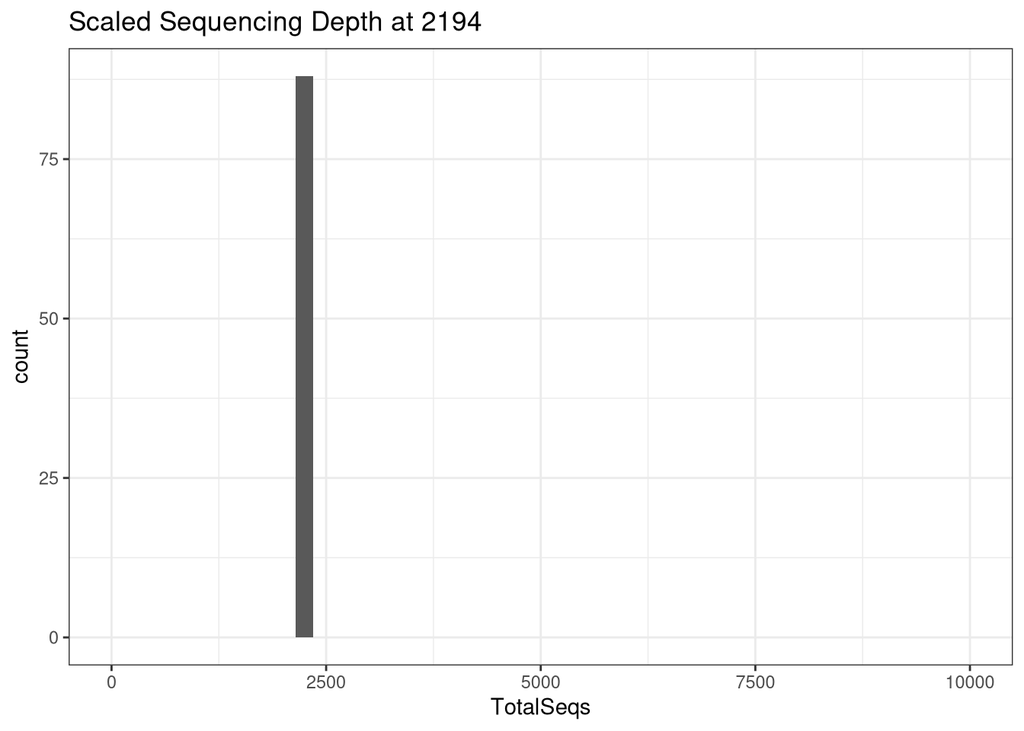

```r
# Plot histogram
scaled_total_seqs_df %>%
  ggplot(aes(x = TotalSeqs)) +
  geom_histogram(bins = 50) +
  scale_x_continuous(limits = c(0, 10000)) +
  labs(title = "Scaled Sequencing Depth at 2194") +
  theme_bw()
```

```r
head(scaled_total_seqs_df)
```

```
##                   TotalSeqs
## 20210602-MA-ABB1F      2192
## 20210602-MA-ABB1P      2184
## 20210602-MA-ABB1W      2195
## 20210602-MA-ABS1F      2189
## 20210602-MA-ABS1P      2197
## 20210602-MA-ABS1W      2195
```

# Calculate & Visualize Community Dissimiliarity

Exploratory analyses from the Paily & Shankar (2016) paper, which is using unconstrained ordination methods like PCoA.

## Sorenson PCoA

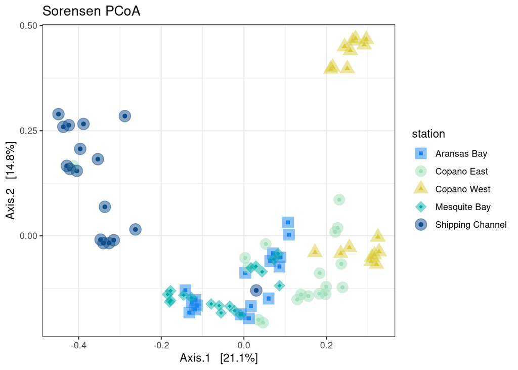

```r
# Calculate sorenson dissimularity: Abundance-unweighted of shared taxa
scaled_soren_pcoa <-
  ordinate(
    physeq = scaled_rooted_physeq,
    method = "PCoA",
    distance = "bray", binary = TRUE)

#str(scaled_soren_pcoa)

# Plot the ordination
soren_station_pcoa <- plot_ordination(
  physeq = scaled_rooted_physeq,
  ordination = scaled_soren_pcoa,
  color = "station",
  shape = "station",
  title = "Sorensen PCoA") +
  geom_point(size=5, alpha = 0.5, aes(color = station)) +
  scale_shape_manual(values = c(15,16,17,18,19,20)) +
  scale_color_manual(values = station_colors) +
  theme_bw()
# Show the plot
soren_station_pcoa
```

*Note that I have removed the PERMANOVA test to below the ordinations. We will come back to it later!*

Here, we are evaluating the shared taxa by presence/absence (abundance-unweighted) in the Sorensen metric.

Note that there is a weird arch or horseshoe-effect in the data. This is likely because we have complete species turnover between our stations. If you have this in your data, please take a look at the paper by [Morton et al., 2017](https://journals.asm.org/doi/10.1128/msystems.00166-16). More on this in NMDS…

Note that:

- Axis 1 = ~21% of variation
- Axis 2 = ~15% of variation

This means we explain 36% of the variation in the data in these two axes.

## Bray-Curtis PCoA

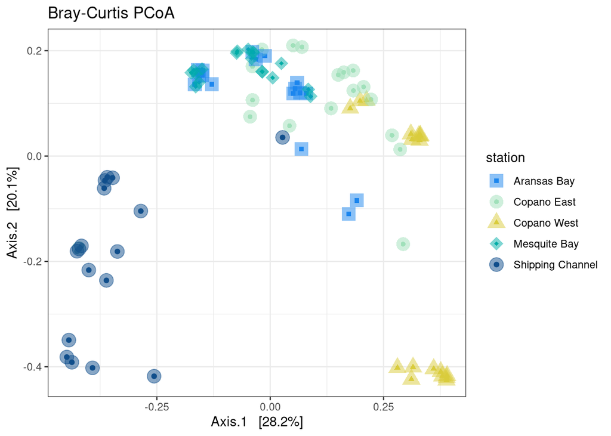

```r
# Calculate the BC distance
scaled_BC_pcoa <-
  ordinate(
    physeq = scaled_rooted_physeq,
    method = "PCoA",
    distance = "bray")

# Plot the PCoA
bray_station_pcoa <-
  plot_ordination(
    physeq = scaled_rooted_physeq,
    ordination = scaled_BC_pcoa,
    color = "station",
    shape = "station",
    title = "Bray-Curtis PCoA") +
  geom_point(size=5, alpha = 0.5, aes(color = station)) +
  scale_shape_manual(values = c(15,16,17,18, 19, 20)) +
  scale_color_manual(values = c(station_colors)) +
  theme_bw()
bray_station_pcoa
```

Here, we are evaluating the shared taxa and then weighting them by their abundances, which provides more influence for species that are more abundant.

Note that there is a weird arch or horseshoe-effect in the data. This is likely because we have complete species turnover between our stations. If you have this in your data, please take a look at the paper by [Morton et al., 2017](https://journals.asm.org/doi/10.1128/msystems.00166-16). More on this in NMDS…

Note that:

- Axis 1 = ~28% of variation
- Axis 2 = ~20% of variation

This means we explain 48% of the variation in the data in these two axes, which is more than the previous plot with the Sorensen Dissimilarity. Abundance does seem to have an influence!!

It also looks like the samples are now separating more within each group than they did a bit more with Sorensen. Please note this with how the Copano West samples are looking between the Bray-Curtis and the Sorensen plots.

## Weighted-Unifrac PCoA

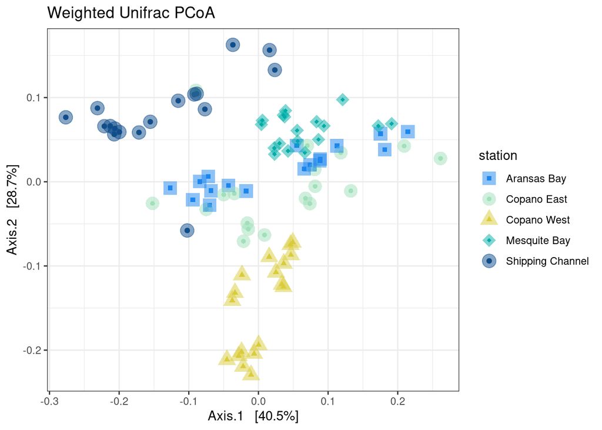

```r
# Calculate the BC distance
scaled_wUNI_pcoa <-
  ordinate(
    physeq = scaled_rooted_physeq,
    method = "PCoA",
    distance = "wunifrac")

# Plot the PCoA
wUNI_station_pcoa <-
  plot_ordination(
    physeq = scaled_rooted_physeq,
    ordination = scaled_wUNI_pcoa,
    color = "station",
    shape = "station",
    title = "Weighted Unifrac PCoA") +
  geom_point(size=5, alpha = 0.5, aes(color = station)) +
  scale_shape_manual(values = c(15,16,17,18, 19, 20)) +
  scale_color_manual(values = c(station_colors)) +
  theme_bw()
wUNI_station_pcoa
```

Here, we are evaluating the shared taxa and then weighting them by their abundances, which provides more influence for species that are more abundant.

Note that:

- Axis 1 = ~41% of variation
- Axis 2 = ~29% of variation

This means we explain *70*% of the variation in the data in these two axes (!!!), which is significantly more than the previous plots with the taxonomic dissimilarity measures. Here, phylogeny seems to be very important! This means that taxa that are abundant are found in different places in the phylogenetic tree. Therefore, the evoultionary distances (aka the branch lengths) and their abundances seem to have a major influence!!

It also looks like the samples are now separating more within each group than they did a bit more with Sorensen. Please note this with how the Copano West samples are looking between the Bray-Curtis and the Sorensen plots.

## Combine PCoAs

Let’s plot all three together into one plot to have a concise visualization of the three metrics.

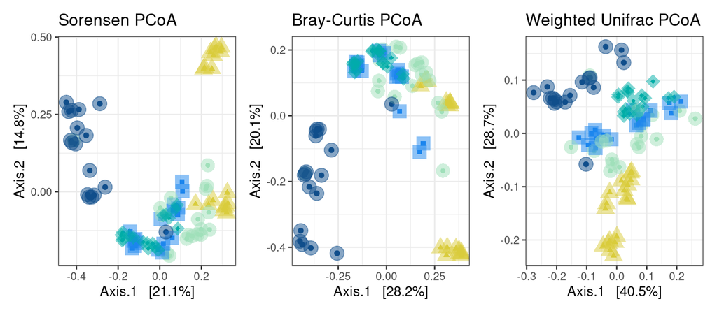

```r
(soren_station_pcoa + theme(legend.position = "none")) +
  (bray_station_pcoa + theme(legend.position = "none")) +
    (wUNI_station_pcoa + theme(legend.position = "none"))
```

## NMDS

### Weighted Unifrac

Since we did 3 of the dissimilarity metrics for the PCoA, let’s just plot one example of them for the NMDS plotting. Here, we will use weighted Unifrac

```r
# Calculate the Weighted Unifrac distance
scaled_wUNI_nmds <-
  ordinate(
    physeq = scaled_rooted_physeq,
    method = "NMDS",
    distance = "wunifrac")
```

```
## *** Best solution repeated 10 times
```

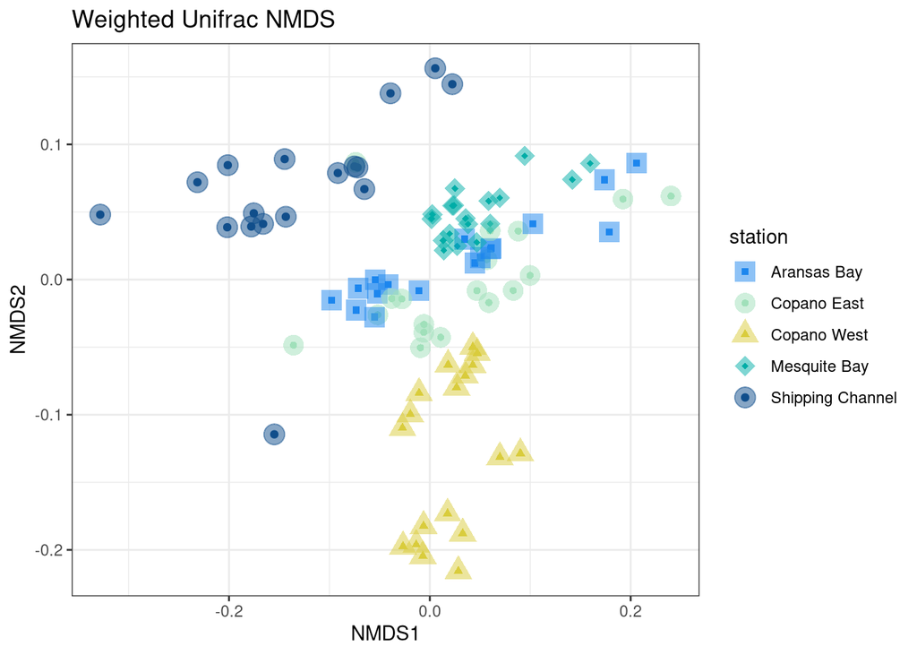

```r
# Plot the PCoA
wUNI_station_nmds <-
  plot_ordination(
    physeq = scaled_rooted_physeq,
    ordination = scaled_wUNI_nmds,
    color = "station",
    shape = "station",
    title = "Weighted Unifrac NMDS") +
  geom_point(size=5, alpha = 0.5, aes(color = station)) +
  scale_shape_manual(values = c(15,16,17,18, 19, 20)) +
  scale_color_manual(values = c(station_colors)) +
  theme_bw()
wUNI_station_nmds
```

In this case, I would always prefer to report the PCoA results because they are linear and provide a lot more post-hoc analyses to follow up with. In addition, it’s helpful to only have 2 axes of variation and show how much variation is explained.

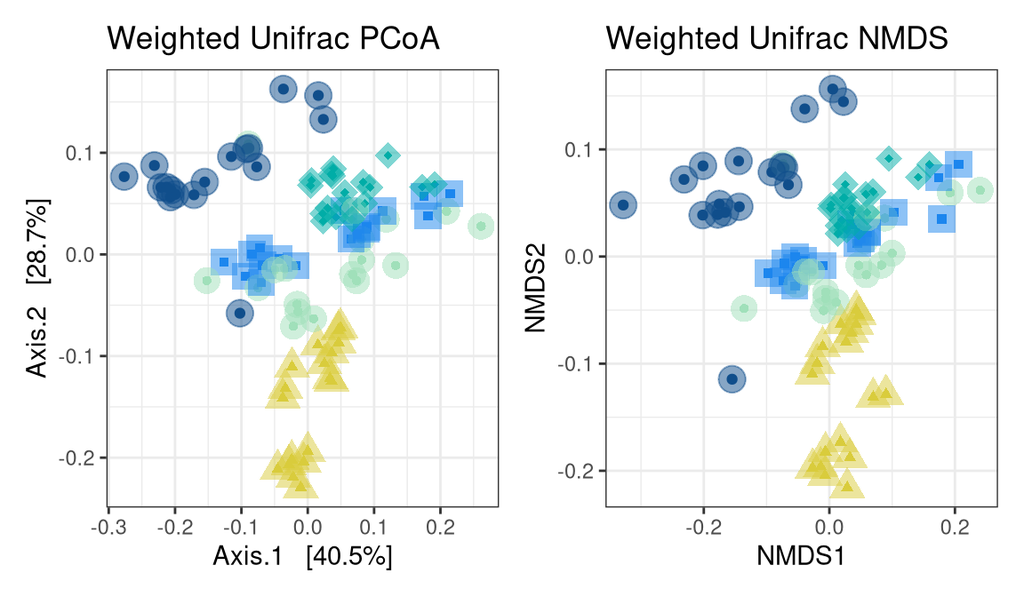

```r
(wUNI_station_pcoa + theme(legend.position = "none")) +
  (wUNI_station_nmds + theme(legend.position = "none"))
```

# Statistical Significance Testing

## PERMANOVA

```r
# Calculate all three of the distance matrices
scaled_sorensen_dist <- phyloseq::distance(scaled_rooted_physeq, method = "bray", binary = TRUE)
scaled_bray_dist <- phyloseq::distance(scaled_rooted_physeq, method = "bray")
scaled_wUnifrac_dist <- phyloseq::distance(scaled_rooted_physeq, method = "wunifrac")

# make a data frame from the sample_data
# All distance matrices will be the same metadata because they
# originate from the same phyloseq object.
metadata <- data.frame(sample_data(scaled_rooted_physeq))

# Adonis test
# In this example we are testing the hypothesis that the five stations
# that were collected have different centroids in the ordination space
# for each of the dissimilarity metrics, we are using a discrete variable
adonis2(scaled_sorensen_dist ~ station, data = metadata)
```

```
## Permutation test for adonis under reduced model
## Terms added sequentially (first to last)
## Permutation: free
## Number of permutations: 999
##
## adonis2(formula = scaled_sorensen_dist ~ station, data = metadata)
##          Df SumOfSqs      R2      F Pr(>F)
## station   4   6.3716 0.29265 8.5848  0.001 ***
## Residual 83  15.4007 0.70735
## Total    87  21.7723 1.00000
## ---
## Signif. codes:  0 '***' 0.001 '**' 0.01 '*' 0.05 '.' 0.1 ' ' 1
```

```r
adonis2(scaled_bray_dist ~ station, data = metadata)
```

```
## Permutation test for adonis under reduced model
## Terms added sequentially (first to last)
## Permutation: free
## Number of permutations: 999
##
## adonis2(formula = scaled_bray_dist ~ station, data = metadata)
##          Df SumOfSqs      R2      F Pr(>F)
## station   4   7.3069 0.38689 13.094  0.001 ***
## Residual 83  11.5794 0.61311
## Total    87  18.8863 1.00000
## ---
## Signif. codes:  0 '***' 0.001 '**' 0.01 '*' 0.05 '.' 0.1 ' ' 1
```

```r
adonis2(scaled_wUnifrac_dist ~ station, data = metadata)
```

```
## Permutation test for adonis under reduced model
## Terms added sequentially (first to last)
## Permutation: free
## Number of permutations: 999
##
## adonis2(formula = scaled_wUnifrac_dist ~ station, data = metadata)
##          Df SumOfSqs      R2      F Pr(>F)
## station   4   1.1233 0.45288 17.176  0.001 ***
## Residual 83   1.3571 0.54712
## Total    87   2.4804 1.00000
## ---
## Signif. codes:  0 '***' 0.001 '**' 0.01 '*' 0.05 '.' 0.1 ' ' 1
```

Note that:

- R2 = the percent variation explained.
- F = the F-Statistic, which represents the importance value.
- Pr(>F) = the pvalue

Above, we see that the most variation is explained by the weighted unifrac, which explains ~45% of the variation in the data and also has the highest F-statistic.

```r
# We might also care about other variables
# Here, we will add date and fraction as variables
# multiplicative model ORDER MATTERS!
adonis2(scaled_sorensen_dist ~ station * date * fraction, data = metadata)
```

```
## Permutation test for adonis under reduced model
## Terms added sequentially (first to last)
## Permutation: free
## Number of permutations: 999
##
## adonis2(formula = scaled_sorensen_dist ~ station * date * fraction, data = metadata)
##                       Df SumOfSqs      R2       F Pr(>F)
## station                4   6.3716 0.29265 12.7392  0.001 ***
## date                   2   2.3935 0.10993  9.5710  0.001 ***
## fraction               2   0.5172 0.02376  2.0683  0.004 **
## station:date           8   3.9412 0.18102  3.9399  0.001 ***
## station:fraction       8   0.9169 0.04212  0.9167  0.699
## date:fraction          4   0.5037 0.02313  1.0070  0.438
## station:date:fraction 16   1.7514 0.08044  0.8754  0.886
## Residual              43   5.3767 0.24695
## Total                 87  21.7723 1.00000
## ---
## Signif. codes:  0 '***' 0.001 '**' 0.01 '*' 0.05 '.' 0.1 ' ' 1
```

```r
adonis2(scaled_bray_dist ~ station * date * fraction, data = metadata)
```

```
## Permutation test for adonis under reduced model
## Terms added sequentially (first to last)
## Permutation: free
## Number of permutations: 999
##
## adonis2(formula = scaled_bray_dist ~ station * date * fraction, data = metadata)
##                       Df SumOfSqs      R2       F Pr(>F)
## station                4   7.3069 0.38689 23.2209  0.001 ***
## date                   2   2.0117 0.10651 12.7859  0.001 ***
## fraction               2   0.7505 0.03974  4.7698  0.001 ***
## station:date           8   3.4783 0.18417  5.5270  0.001 ***
## station:fraction       8   0.7016 0.03715  1.1149  0.253
## date:fraction          4   0.3056 0.01618  0.9713  0.475
## station:date:fraction 16   0.9490 0.05025  0.7540  0.974
## Residual              43   3.3827 0.17911
## Total                 87  18.8863 1.00000
## ---
## Signif. codes:  0 '***' 0.001 '**' 0.01 '*' 0.05 '.' 0.1 ' ' 1
```

```r
# Note that the ORDER MATTERS!
adonis2(scaled_wUnifrac_dist ~ station * date * fraction, data = metadata)
```

```
## Permutation test for adonis under reduced model
## Terms added sequentially (first to last)
## Permutation: free
## Number of permutations: 999
##
## adonis2(formula = scaled_wUnifrac_dist ~ station * date * fraction, data = metadata)
##                       Df SumOfSqs      R2       F Pr(>F)
## station                4  1.12332 0.45288 27.9816  0.001 ***
## date                   2  0.17318 0.06982  8.6277  0.001 ***
## fraction               2  0.22887 0.09227 11.4023  0.001 ***
## station:date           8  0.32313 0.13027  4.0245  0.001 ***
## station:fraction       8  0.07703 0.03106  0.9594  0.519
## date:fraction          4  0.02648 0.01068  0.6596  0.813
## station:date:fraction 16  0.09684 0.03904  0.6031  0.989
## Residual              43  0.43156 0.17399
## Total                 87  2.48042 1.00000
## ---
## Signif. codes:  0 '***' 0.001 '**' 0.01 '*' 0.05 '.' 0.1 ' ' 1
```

```r
adonis2(scaled_wUnifrac_dist ~ date * station * fraction, data = metadata)
```

```
## Permutation test for adonis under reduced model
## Terms added sequentially (first to last)
## Permutation: free
## Number of permutations: 999
##
## adonis2(formula = scaled_wUnifrac_dist ~ date * station * fraction, data = metadata)
##                       Df SumOfSqs      R2       F Pr(>F)
## date                   2  0.17259 0.06958  8.5984  0.001 ***
## station                4  1.12391 0.45311 27.9963  0.001 ***
## fraction               2  0.22887 0.09227 11.4023  0.001 ***
## date:station           8  0.32313 0.13027  4.0245  0.001 ***
## date:fraction          4  0.02633 0.01062  0.6559  0.845
## station:fraction       8  0.07718 0.03111  0.9612  0.536
## date:station:fraction 16  0.09684 0.03904  0.6031  0.992
## Residual              43  0.43156 0.17399
## Total                 87  2.48042 1.00000
## ---
## Signif. codes:  0 '***' 0.001 '**' 0.01 '*' 0.05 '.' 0.1 ' ' 1
```

We can also run tests that include additive (+) or multipliciatve models, which include the interaction term between variables.

## BetaDispR

The PERMANOVA is sensitive to variance/dispersion in the data. Therefore, we need to run a homogeneity of dispersion test to test for the sensitivity of our PERMANOVA results to variance.

```r
# Homogeneity of Disperson test with beta dispr
# Sorensen
beta_soren_station <- betadisper(scaled_sorensen_dist, metadata$station)
permutest(beta_soren_station)
```

```
##
## Permutation test for homogeneity of multivariate dispersions
## Permutation: free
## Number of permutations: 999
##
## Response: Distances
##           Df  Sum Sq  Mean Sq      F N.Perm Pr(>F)
## Groups     4 0.18429 0.046073 6.3863    999  0.002 **
## Residuals 83 0.59878 0.007214
## ---
## Signif. codes:  0 '***' 0.001 '**' 0.01 '*' 0.05 '.' 0.1 ' ' 1
```

```r
# Bray-curtis
beta_bray_station <- betadisper(scaled_bray_dist, metadata$station)
permutest(beta_bray_station)
```

```
##
## Permutation test for homogeneity of multivariate dispersions
## Permutation: free
## Number of permutations: 999
##
## Response: Distances
##           Df  Sum Sq  Mean Sq      F N.Perm Pr(>F)
## Groups     4 0.37117 0.092794 7.0268    999  0.001 ***
## Residuals 83 1.09607 0.013206
## ---
## Signif. codes:  0 '***' 0.001 '**' 0.01 '*' 0.05 '.' 0.1 ' ' 1
```

```r
# Weighted Unifrac
beta_bray_station <- betadisper(scaled_wUnifrac_dist, metadata$station)
permutest(beta_bray_station)
```

```
##
## Permutation test for homogeneity of multivariate dispersions
## Permutation: free
## Number of permutations: 999
##
## Response: Distances
##           Df   Sum Sq  Mean Sq     F N.Perm Pr(>F)
## Groups     4 0.042101 0.010525 4.195    999  0.006 **
## Residuals 83 0.208244 0.002509
## ---
## Signif. codes:  0 '***' 0.001 '**' 0.01 '*' 0.05 '.' 0.1 ' ' 1
```

Above, our variance is impacted by station. Therefore, we need to be very careful about what we conclude about our data.

# Taxonomic Composition

## Phylum

```r
# Set the phylum colors
phylum_colors <- c(
  Acidobacteriota = "navy",
  Actinobacteriota = "darkslategray2",
  Armatimonadota = "deeppink1",
  Alphaproteobacteria = "plum2",
  Bacteroidota = "gold",
  Betaproteobacteria = "plum1",
  Bdellovibrionota = "red1",
  Chloroflexi="black",
  Crenarchaeota = "firebrick",
  Cyanobacteria = "limegreen",
  Deltaproteobacteria = "grey",
  Desulfobacterota="magenta",
  Firmicutes = "#3E9B96",
  Gammaproteobacteria = "greenyellow",
  "Marinimicrobia (SAR406 clade)" = "yellow",
  Myxococcota = "#B5D6AA",
  Nitrospirota = "palevioletred1",
  Proteobacteria = "royalblue",
  Planctomycetota = "darkorange",
  "SAR324 clade(Marine group B)" = "olivedrab",
  #Proteobacteria_unclassified = "greenyellow",
  Thermoplasmatota = "green",
  Verrucomicrobiota = "darkorchid1")
 # Other = "grey")
```

#### Plot Phylum Composition

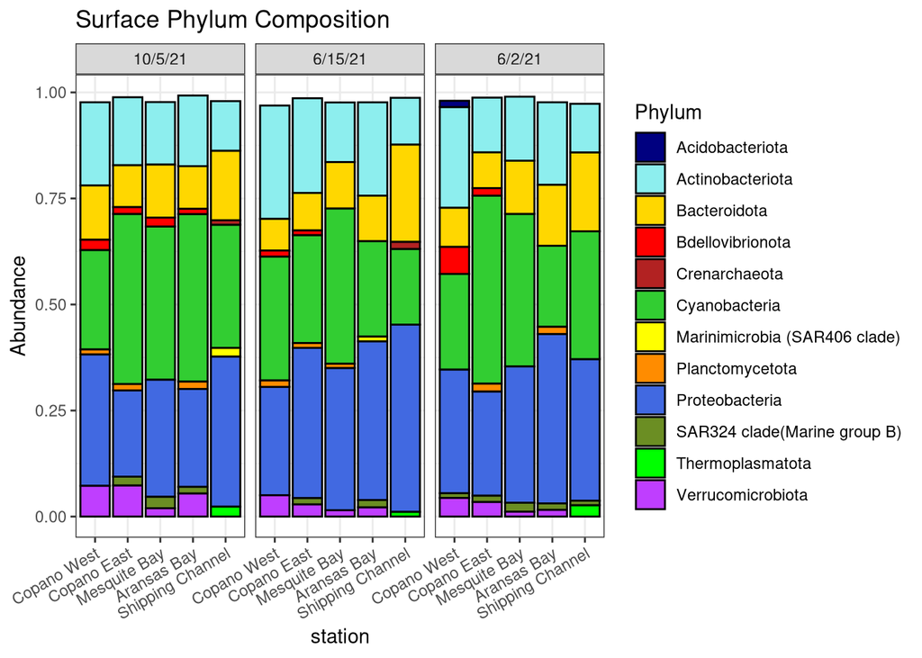

```r
# Goal is to calculate the phylum relative abundance
# Note: the read depth must be normalized in some way: scaled_reads
phylum_df <-
  scaled_rooted_physeq %>%
  # agglomerate at the phylum level
  tax_glom(taxrank = "Phylum") %>%
  # Transform counts to relative abundance
  transform_sample_counts(function (x) {x/sum(x)}) %>%
  # Melt to a long format
  psmelt() %>%
  # Filter out phyla that are less than one percent - get rid of low abundant Phyla
  dplyr::filter(Abundance > 0.01) %>%
  # fix the order of date
  mutate(data = fct_relevel(date, c("6/2/21", "6/15/21", "10/5/21")),
        # Re-write stations
         station = fct_relevel(station, c("Copano West", "Copano East",
                        "Mesquite Bay", "Aransas Bay", "Shipping Channel")))

# Stacked bar plot with all Phyla
# Plot Phylum Abundances - make sure to load phylum_colors
phylum_df %>%
  # Warning: Its important to have one sample per x value,
  # Otherwise, it will take the sum between multiple samples
  dplyr::filter(depth == 0.0) %>%
  dplyr::filter(fraction == "Whole") %>%
  ggplot(aes(x = station, y = Abundance, fill = Phylum)) +
  facet_grid(.~date) +
  geom_bar(stat = "identity", color = "black") +
  labs(title = "Surface Phylum Composition") +
  scale_fill_manual(values = phylum_colors) +
  theme_bw() +
  theme(axis.text.x = element_text(angle = 30, hjust = 1, vjust = 1))
```

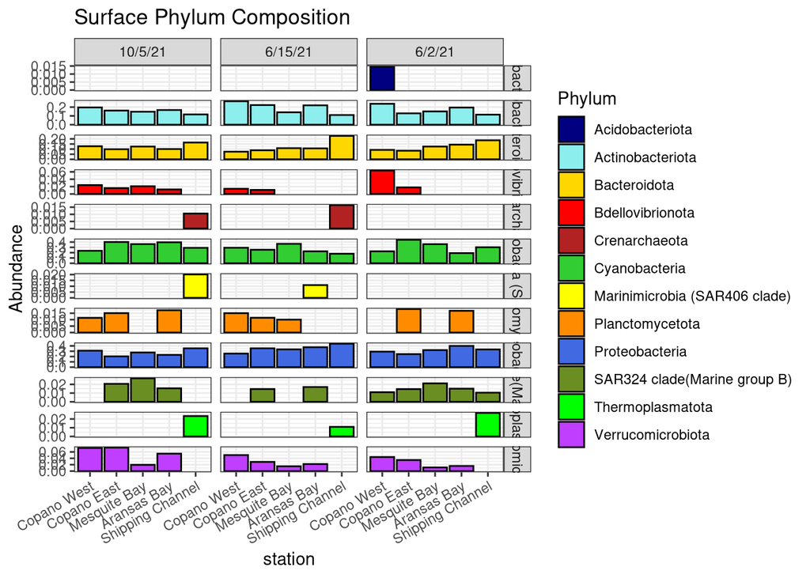

```r
# Make each Phyla its own row
phylum_df %>%
  dplyr::filter(depth == 0.0) %>%
  dplyr::filter(fraction == "Whole") %>%
  ggplot(aes(x = station, y = Abundance, fill = Phylum)) +
  facet_grid(Phylum~date, scale = "free") +
  geom_bar(stat = "identity", color = "black") +
  labs(title = "Surface Phylum Composition") +
  scale_fill_manual(values = phylum_colors) +
  theme_bw() +
  theme(axis.text.x = element_text(angle = 30, hjust = 1, vjust = 1))
```

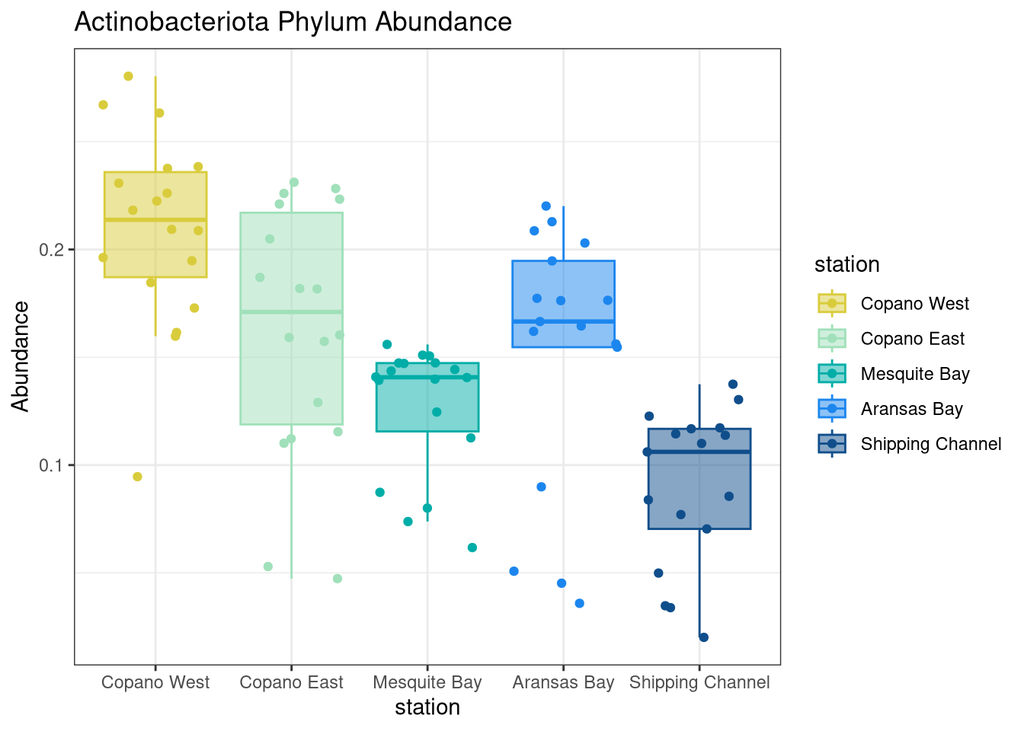

```r
# Narrow in on a specific group
# Actinobacteriota - y: abundance, x: station, dot plot + boxplot
phylum_df %>%
  dplyr::filter(Phylum == "Actinobacteriota") %>%
  # build the plot
  ggplot(aes(x = station, y = Abundance, fill = station, color = station)) +
  geom_boxplot(alpha = 0.5, outlier.shape = NA) +
  # outliers not plotted here in boxplot
  geom_jitter() +
  theme_bw() +
  labs(title = "Actinobacteriota Phylum Abundance") +
  scale_color_manual(values = station_colors) +
  scale_fill_manual(values = station_colors)
```

```r
# for statistics, Kruskall-Wallis followed by a Tukey's Posthoc test
# These are non parametric
```

## Family

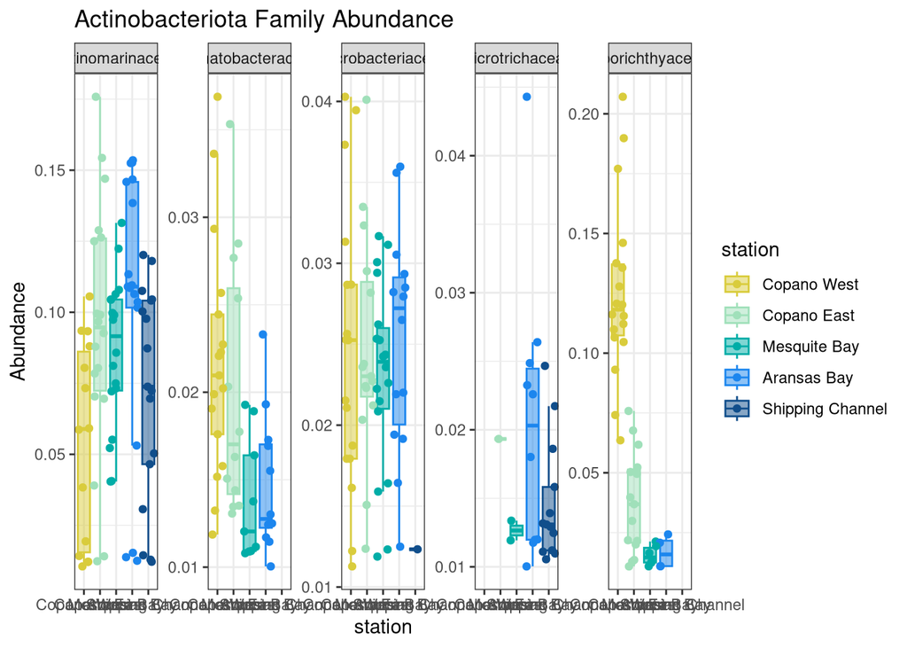

```r
family_df <-
  scaled_rooted_physeq %>%
  # agglomerate at the phylum level
  tax_glom(taxrank = "Family") %>%
  # Transform counts to relative abundance
  transform_sample_counts(function (x) {x/sum(x)}) %>%
  # Melt to a long format
  psmelt() %>%
  # Filter out phyla that are less than one percent - get rid of low abundant Phyla
  dplyr::filter(Abundance > 0.01) %>%
  # fix the order of date
  mutate(data = fct_relevel(date, c("6/2/21", "6/15/21", "10/5/21")),
        # Re-write stations
         station = fct_relevel(station, c("Copano West", "Copano East",
                        "Mesquite Bay", "Aransas Bay", "Shipping Channel")))

family_df %>%
  dplyr::filter(Phylum == "Actinobacteriota") %>%
  # build the plot
  ggplot(aes(x = station, y = Abundance,
             fill = station, color = station)) +
  facet_wrap(.~Family, scales = "free_y", nrow = 1) +
  geom_boxplot(alpha = 0.5, outlier.shape = NA) +
  # outliers not plotted here in boxplot
  geom_jitter() +
  theme_bw() +
  labs(title = "Actinobacteriota Family Abundance") +
  scale_color_manual(values = station_colors) +
  scale_fill_manual(values = station_colors)
```